# Yelp Data Analysis

Data Wrangling Project

Wanting Tan

April 27, 2018

## 1. Introduction

Yelp Dataset Challenge is a gread exercise for us to do interesting data exploration and practice what we have learned in the class. Data wrangling is such an important work that always requires most of the time of data analysis. Therefore, it worth our time to deep dive.

In this project, I used two **yelp datasets** (Business.csv and Reviews.csv) and **geocode data** from google map. For restaurant rating data, I plotted distribution of ratings, provided average ratings by state and spotted where most 5-star restaurants are located. For the last part, I built a leaflet plot, which shows the distribution clearly.

For customer reviews, I focused on **sentiment analysis** for both the restaurant who has the most 5-star reviews and the one who has the most 1-star reviews. I extracted top ten most common words in reviews and analyzed negative reviews and positive reviews of each specific restaurant.

For the final part, I made a conclusion and some interesting findings. This project really helps me to combine all the tools I learned together and put into practice. Nice training!

## 2. Preparation

### 2.1 Load Libraries

```r
library(jsonlite)
library(textcat)
library(dplyr)
library(tidyverse)
library(extrafont)
library(ggplot2)
library(leaflet)
library(ggmap)
library(pander)
library(knitr)
library(tidytext)
library(wordcloud)
library(textcat)
library(googleway)
library(DT)
```

### 2.2 Clean The Data

The dataset comes from Yelp Dataset Challenge Website:https://www.yelp.com/dataset/challenge. I downloaded **JSON file** for my analysis. This dataset contains information about the businesses listed on Yelp for selected states and provinces in the US and Europe.

Here is my code to read JSON file in R:

```r
business <- stream_in(file("business.json"))
reviews <- stream_in(file("reviews.json"))
```

After reading JSON data, I used flatten() to eliminate the structure, converting them to data frame and saved as “yelp_review.csv” and “yelp_business.csv”.

```r
reviews<-read.csv("yelp_review.csv")
business<-read.csv("yelp_business.csv")

#only consider restaurants and food field
restaurants <- business[grepl('Restaurant|restaurant|food|Food', business$categories),]
nrow(restaurants) #69079
write.csv(restaurants,file="restaurants.csv")

#cleaning up Reviews Data to filter only Restaurant Data
reviews_food<-reviews %>% filter(business_id %in% restaurants$business_id)
nrow(reviews_food) #3540258
write.csv(reviews_food,file="reviews_food.csv")
```

I want to focus only on restaurants and food, so I removed unnecessary observations by using regular expression. Then, I saved them in csv files and those are clean datasets I’m going to use for my data analysis. There are in total 69079 restaurants business data and 3540258 customer reviews for these restaurants.

Here are two previews for my clean data:

##### **Business Data for Restaurants**

|  | X | business_id | name | neighborhood | address | city | state | postal_code | latitude | longitude | stars | review_count | is_open | categories |
| --- | --- | --- | --- | --- | --- | --- | --- | --- | --- | --- | --- | --- | --- | --- |
| 1 | 5 | PfOCPjBrlQAnz__NXj9h_w | "Brick House Tavern + Tap" |  | "581 Howe Ave" | Cuyahoga Falls | OH | 44221 | 41.1195346 | -81.4756898 | 3.5 | 116 | 1 | American (New);Nightlife;Bars;Sandwiches;American (Traditional);Burgers;Restaurants |
| 2 | 6 | o9eMRCWt5PkpLDE0gOPtcQ | "Messina" |  | "Richterstr. 11" | Stuttgart | BW | 70567 | 48.7272 | 9.14795 | 4 | 5 | 1 | Italian;Restaurants |
| 3 | 9 | EsMcGiZaQuG1OOvL9iUFug | "Any Given Sundae" |  | "2612 Brandt School Rd" | Wexford | PA | 15090 | 40.6151022445 | -80.0913487465 | 5 | 15 | 1 | Coffee &amp; Tea;Ice Cream &amp; Frozen Yogurt;Food |

##### **Reviews Data for Restaurants**

```
## Observations: 3,540,258
## Variables: 10
## $ X           <int> 1, 2, 3, 4, 5, 6, 7, 8, 9, 10, 11, 12, 13, 14, 15,...
## $ review_id   <fct> vkVSCC7xljjrAI4UGfnKEQ, n6QzIUObkYshz4dz2QRJTw, MV...
## $ user_id     <fct> bv2nCi5Qv5vroFiqKGopiw, bv2nCi5Qv5vroFiqKGopiw, bv...
## $ business_id <fct> AEx2SYEUJmTxVVB18LlCwA, VR6GpWIda3SfvPC-lg9H3w, CK...
## $ stars       <int> 5, 5, 5, 4, 4, 4, 4, 3, 4, 3, 3, 5, 4, 3, 3, 1, 3,...
## $ date        <fct> 2016-05-28, 2016-05-28, 2016-05-28, 2016-05-28, 20...
## $ text        <fct> Super simple place but amazing nonetheless. It's b...
## $ useful      <int> 0, 0, 0, 0, 0, 0, 1, 1, 1, 5, 2, 2, 0, 2, 4, 9, 1,...
## $ funny       <int> 0, 0, 0, 0, 0, 0, 0, 0, 0, 0, 1, 0, 0, 0, 0, 2, 0,...
## $ cool        <int> 0, 0, 0, 0, 0, 2, 0, 0, 0, 1, 1, 1, 0, 0, 0, 1, 0,...
```

## 3. Rating Data Analysis

### 3.1 Distribution of Ratings

The following plot shows the distribution of ratings by users. We can see the bar plot shows a roughly increasing trend. There are a lot more 4 and 5 star ratings than 1,2 and 3. We could say people tend to review things they like. That means people seems to me more likely to write positive feelings rather than a negative one.

The fact that 1 star ratings are more than 2 star ratings surprised me a little bit. I guess that people tend to express their anger if they had a very bad experience.

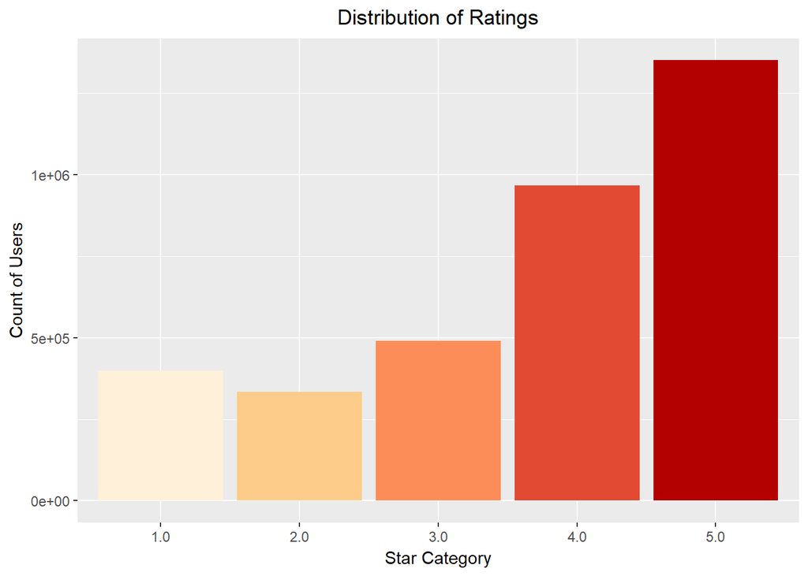

### 3.2 Average Review Ratings Grouped by State

I want to know which state tends to give higher ratings so I made the following table to show the average review ratings of each state. State here contains not only states in the United States but also some states in the Canada and Europe. “total business” is the total number of restaurants in a specific state. “ave_rating” is the mean of ratings of all these restaurants. I arranged total business in decreasing order and showed only first 10 rows of the table.

I didn’t sort the table by average rating because if I did that it would shown many states with very high average ratings but only 1 total number of restaurant, which is meaningless.

| state | total_business | avg_rating |
| --- | --- | --- |
| ON | 16845 | 3.41 |
| AZ | 13826 | 3.46 |
| NV | 9263 | 3.47 |
| OH | 6031 | 3.48 |
| QC | 5941 | 3.7 |
| NC | 4969 | 3.46 |
| PA | 4686 | 3.55 |
| BW | 2023 | 3.78 |
| WI | 1984 | 3.52 |
| EDH | 1906 | 3.84 |

This is the bar plot of table above. I sorted the ratings in the table in decreasing order. According to the plot, El Dorado Hills(EDH) in the US, Baden-Württemberg(BW) in German and Quebec(QC) in Canada have highest scores. Although Ontaria(ON) has the highest number of restaurants, it has relatively lower ratings.

[figure not shown]

### 3.3 Where Are Most 5-star Restaurants Located?

Wherever I go, I always try to find 5-star restaurants nearby so that I won’t waste my time and money. So for this part, I want to find where most 5-star restaurants are located. The first step is to find 5-star restaurants. The following table is top ten 5-star restaurants ordered by the number of reviews.

| name | city | state | review_count | stars |
| --- | --- | --- | --- | --- |
| “Little Miss BBQ” | Phoenix | AZ | 1463 | 5 |
| “Brew Tea Bar” | Las Vegas | NV | 1165 | 5 |
| “Gelatology” | Las Vegas | NV | 506 | 5 |
| “Poke Express” | North Las Vegas | NV | 494 | 5 |
| “Green Corner Restaurant” | Mesa | AZ | 355 | 5 |
| “Art of Flavors” | Las Vegas | NV | 352 | 5 |
| “Worth Takeaway” | Mesa | AZ | 336 | 5 |
| “Desert Wind Coffee Roasters” | Las Vegas | NV | 327 | 5 |
| “Meraki Greek Grill” | Las Vegas | NV | 327 | 5 |
| “Doglicious Hot Dogs” | Glendale | AZ | 263 | 5 |

After knowing names and addresses of these restaurants, we need to find out the longitude and latitude of these places. I tried to use **geocode** function but it can’t read all the places I selected. Therefore, I asked for an api key from google map website so that I can use **googleway** package to get location. Below is my leaflet plot.

When you click the marker in the plot, it will show the city name and the number of 5-star restaurant in that city. When you shrink the plot, you will see there are some makers in the Europe. We can see that 5 star restaurants are mainly located in east coast and west coast of United States. It is reasonable because the population in these two areas are higher than other areas. So, the corresponding number of restaurant should be higher.

[interactive chart not shown]

## 4. Review Data Analysis

For the review part, I choose to do sentiment analysis. I selected the restaurant that has most 5 star reviews and the restaurant that has most 1 star reviews as my objects and did positive review analysis and negative review analysis respectively. I expect that my result would show why popular restaurant is popular and how the worse one can improve.

### 4.1 Sentiment Analysis for The Restaurant Has Most 5-star Reviews

#### 4.1.1 Find The Restaurant Has Most 5-star Reviews

| name | city | state | count |
| --- | --- | --- | --- |
| “Mon Ami Gabi” | Las Vegas | NV | 3280 |
| “Bacchanal Buffet” | Las Vegas | NV | 2725 |
| “Earl of Sandwich” | Las Vegas | NV | 2443 |
| “Gangnam Asian BBQ Dining” | Las Vegas | NV | 2280 |
| “Gordon Ramsay BurGR” | Las Vegas | NV | 2198 |
| “Lotus of Siam” | Las Vegas | NV | 2162 |
| “Hash House A Go Go” | Las Vegas | NV | 1888 |
| “Wicked Spoon” | Las Vegas | NV | 1844 |
| “Secret Pizza” | Las Vegas | NV | 1631 |
| “Egg & I” | Las Vegas | NV | 1616 |

The table above shows the top 10 restaurants that have most 5-star reviews. “name” is the name of restaurant.“city” “state” is the place the restaurant located in. “count” is the number of 5 star reviews. We can see the first 10 restaurants all come from Las Vegas. It is partly because in the original dataset, Las Vegas has the most business parties in Yelp.

I also plotted bar plot for this table. I prefer the bar plot because it shows information more clearly and straightforward. We can easily notice that “Mon Ami Gabi” in Las Vegas has the most 5 star reviews-3280 reviews. Therefore, I chose “Mon Ami Gabi” as my object for positive review analysis.

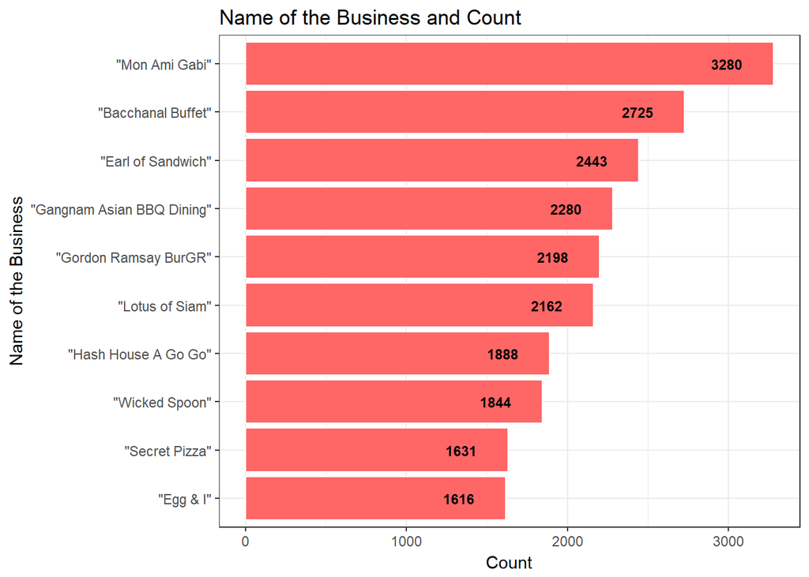

#### 4.1.2 Top Ten Most Common Words of “Mon Ami Gabi”

First, I calculated top ten most commen words in reviews. Below is the summary bar plot.

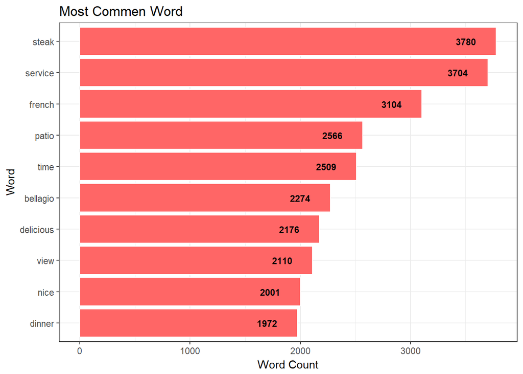

From the plot above, we can see that some positive words shows very frequently in reviews such as “delicious” “nice”. This is not surprising because “Mon Ami Gabi” has most good reviews. However, with only one word we can hardly get information from nouns such as “steak”, “service”, “french”. Therefore, it’s time for Bigram to show up!

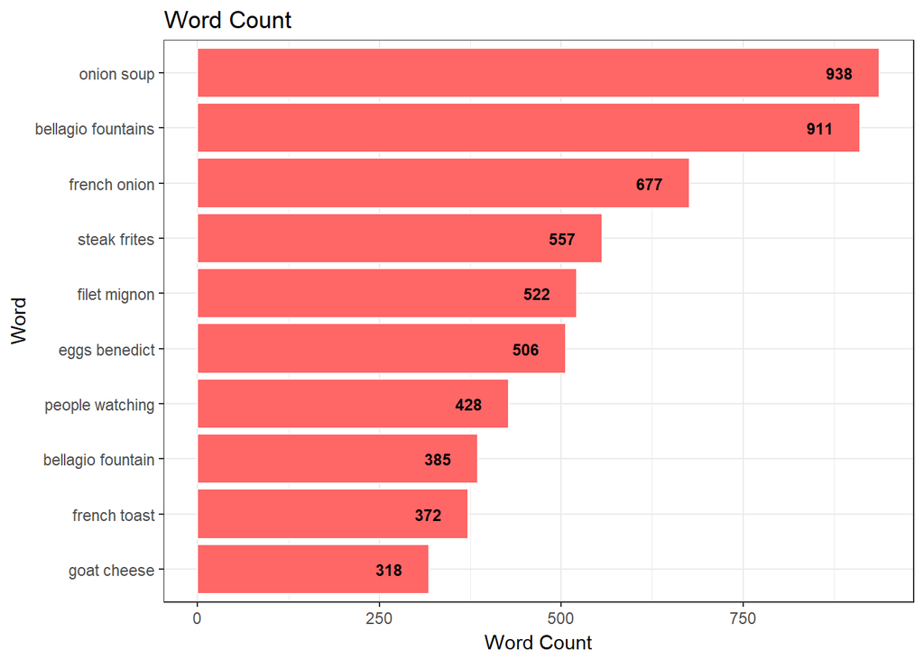

Bigram plot can give us more information about this restaurant. Onion soup and Bellagio fountains might be the biggest characteristics of “Mon Ami Gabi”. I could also know some delicious dishes from these reviews such as Steak frites, French Onion, Eggs benedict, Filet mignon.

I made a word cloud as well just for fun. The height of each word in this picture shows the frequency of occurrence of the word in the entire text. The words steak, service, french, delicious are the popular words in the reviews, which is correspondent to the bar plot of common words.

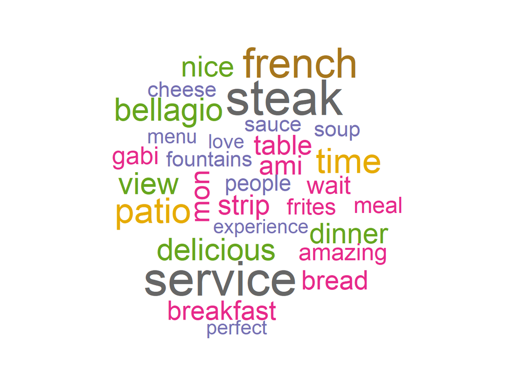

#### 4.1.3 Sentiment Analysis for “Mon Ami Gabi”

First, I used AFINN sentiment lexicon to provide numeric scores for each word and displayed them in following table.

| word | occurences | contribution |
| --- | --- | --- |
| amazing | 1 | 4 |
| ass | 1 | -4 |
| asshole | 1 | -4 |
| awesome | 1 | 4 |
| bitch | 1 | -5 |
| breathtaking | 1 | 5 |
| brilliant | 1 | 4 |
| bullshit | 1 | -4 |

Second, I calculated sentiment scores for all the reviews using AFINN sentiment lexicon. The following table shows first 5 of them. “words” is the number of contributed words in a given review. “sentiment” is the average score of thoes words.

| review_id | sentiment | words |
| --- | --- | --- |
| -_TeC2MMAFp7WRK_hBRqjA | -0.8 | 10 |
| -1fUJDkUaElaP_0YOd8BvA | 1.5 | 32 |
| -2NfC5Dn7ebKrZwSw-X1jg | 2.5 | 8 |
| -31r82MiRcK4DdaOA4Himw | -0.125 | 8 |
| -32pNTk6uUjML6WLaJeP9g | 1.4 | 10 |

#### 4.1.4 Positive Review Analysis

Then, I extracted top three most positive reviews. After examing them, I noticed that although these reviews were written in different years, nearly all of the reviews mentioned good service, nice decoration and atmosphere. They also point out their favorite food: onion soup, steak, pudding and etc.

These information shows advantages of “Mon Ami Gabi” that are attractive to customers and should be kept in the future.

|  | date | sentiment | text |
| --- | --- | --- | --- |
| 1 | 2011-04-28 | 3.66666666666667 | This place is amazing!!! Food is superb and the customer service is out of this world. After a seating mix up the hostess reseated us in the best seat in the whole restaraunt with an amazing view of B… |
| 2 | 2017-02-27 | 3.6 | Wonderful. This was my second time there. Great food. Amazing service. Got the seafood crepe, which came with scallops and shrimp. Shrimp was on dry side, but the scallops were perfect. Ordered the ba… |
| 3 | 2012-08-27 | 3.6 | Second time here - this time with the Wife and Son. The wait for an awesome outside table (actually on the border of the inside dining room and outside patio) was terrific - great people watching spot… |

### 4.2 Sentiment Analysis for The Restaurant Has Most 1-star Reviews

For this part, I want to see the opposite side–find the least popular restaurant. I revised my previous code a little bit and got following table and plot. The place that has most 1 star reviews is “MGM Grand Hotel”. However, when I did sentiment analysis for this hotel, I found most reviews focused on hotel facilities rather than food. That’s not what I want to study so I changed my object the second one–“Bacchanal Buffet”

| name | city | state | Count |
| --- | --- | --- | --- |
| “MGM Grand Hotel” | Las Vegas | NV | 758 |
| “Bacchanal Buffet” | Las Vegas | NV | 669 |
| “Hakkasan Nightclub” | Las Vegas | NV | 583 |
| “Serendipity 3” | Las Vegas | NV | 571 |
| “Pampas Churrascaria Brazilian Grille” | Las Vegas | NV | 478 |
| “Hooters Casino Hotel Las Vegas” | Las Vegas | NV | 473 |
| “Wicked Spoon” | Las Vegas | NV | 409 |
| “The Buffet at Bellagio” | Las Vegas | NV | 376 |
| “Pho Kim Long” | Las Vegas | NV | 374 |
| “Tao Nightclub” | Las Vegas | NV | 364 |

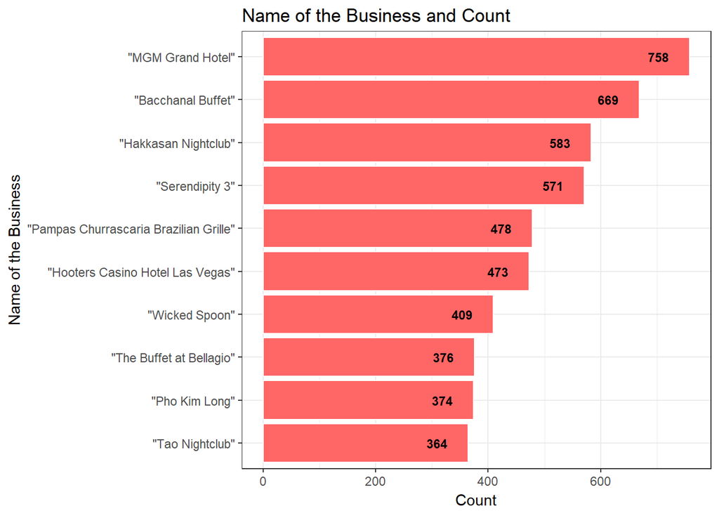

#### 4.2.1 Top Ten Most Common Words of “Bacchanal Buffet”

Similar to what we have done to“Mon Ami Gabi”. I directly calculate the bigram. From the plot below, we notice that crab legs has a very high appearance frequency. It must be a special dish in this restaurant. Then followed by prime rib, dim sum, king crab, etc. I guess that it might be a seafood restaurant.

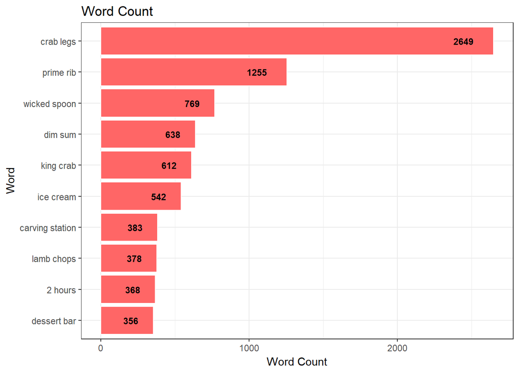

#### 4.2.2 Sentiment Analysis for “Bacchanal Buffet”

Same as before, I used AFINN sentiment lexicon to provide numeric scores for each word and displayed them in following table.

| word | occurences | contribution |
| --- | --- | --- |
| amazing | 1 | 4 |
| ass | 1 | -4 |
| asshole | 1 | -4 |
| awesome | 1 | 4 |
| bastard | 1 | -5 |
| bastards | 1 | -5 |
| bitch | 1 | -5 |
| breathtaking | 1 | 5 |

Then, I calculated sentiment scores for all the reviews using AFINN sentiment lexicon. The second table shows first 5 of them. “words” is the number of contributed words in a given review. “sentiment” is the average score of thoes words.

| review_id | sentiment | words |
| --- | --- | --- |
| –1h6ROOo2XEsLQK8uKvaQ | 1.5 | 6 |
| -_zAczJfPIwLtuiQJyxnqw | 2.86 | 7 |
| -1sn-YoIMEhH7yjk6tR8DQ | 0.6 | 5 |
| -28T41kjGIKfapLuPvS9Ow | 1.33 | 12 |
| -3EMV8zNQvOuWMjlddQeIQ | 0.222 | 9 |

#### 4.2.3 Negative Review Analysis

These information shows drawbacks of “Bacchanal Buffet” that should be improved in the future.

|  | date | sentiment | text |
| --- | --- | --- | --- |
| 1 | 2016-12-27 | -2.83333333333333 | Service was horrible. Food was horrible. That's why I deleted my past review. What a horrible revisit to this place. Everything about it was bad. The food. The service. I mean come on. The waiter has … |
| 2 | 2017-01-08 | -2.66666666666667 | This place sucks so fucking bad. We are waiting in line for almost one hour. They only let VIP members taking the available sits as soon as possible. My legs are fucking hurt right now and I just want… |
| 3 | 2017-03-16 | -2.2 | Service sucks! Server didn't even bother to check our table. I have to set a side my dirty plates on the other side of my table to be able have a space on our table. They give us 2 silverware set up, … |

Besides, I found that although many people gave only 1 star reviews, there were not many complaints about the food. On the contrary, I find many good reviews about the food there.

The following table is several positive reviews of “Bacchanal Buffet”. They all mentioned delicious food there. Therefore, I think this restaurant has the potential to be popular since there are still many people that are willing to wait for it as long as they can improve the waiting system.

|  | date | sentiment | text |
| --- | --- | --- | --- |
| 1 | 2017-10-07 | 4 | My husband and I have lived in Vegas for 12 years and had never been to this buffet. We decided to try it out as a celebratory dinner for our wedding anniversary. Can I just say it was absolutely amaz… |
| 2 | 2014-01-31 | 3.42857142857143 | This Buffet was very good the design inside was amazing i love the look of the different sections. I only give it 3 stars because overall the food was good it didn't WOW me. But for the dessert sectio… |
| 3 | 2014-07-29 | 3.4 | I ate here several days ago for lunch. This was probably my 5th time here. It was so over the top for a lunch buffet I had to post this. Some of the items that were really just awesome were. Beef Ribs… |

## 5. Conclusion and Findings

In this project, I mainly focused on rating data analysis and review data analysis. For rating part, I did rating distribution plot, grouped average ratings by state and built a leaflet plot to show the location of most 5-star restaurants.

Here’s some interesting findings for this part:

- People tend to write a review for a positive experience than a negative one.
- El Dorado Hills(EDH) in the US, Baden-Württemberg(BW) in German and Quebec(QC) in Canada have highest rating scores. Probably they are the right places to find most delicious food.
- Most 5-star restaurants in the US are located in North East America and South West America at least for this dataset. Las Vegas has the most business parties in Yelp.

For review data analysis, I chose to do sentiment analysis because it can point out a direction for business owners to find out which aspect of the business they need to improve and which part needs to keep. I chose two specific restaurants–“Mon Ami Gabi” and “Bacchanal Buffet” as my objects and did detailed sentiment analysis to them.

That all my data wrangling project. Thanks for your reading.